# Socio-economic indicators for 10 european countries in 2014 - 2020

Edyta Pszczółkowska, Anna Sikora

02 czerwiec, 2022

[figure not shown]

Belgium

# Belgium : socio-economic indicators 2014 - 2018

The aim of this report is to present the economy and social conditions in 2014 - 2018 .

Our analysis will be divided on four areas using the following variables:

- economy:
  - GDP per capita
  - Export as GDP percent
  - Import as GDP percent
  - RD as GDP percent - expenses on research and development expressed as % of GDP
- Population:
  - population
  - birth rate - total number of live births per 1,000 population
  - life expectation by 65
  - life expectation by birth
- Unemployment:
  - unemployment rate
  - long term unemployment
- Women situation:
  - fertility rate - total number of children that would be born to each woman if she were to live to the end of her child-bearing years
  - age at 1st child - mean age of women while giving a birth to 1st child
  - gender pay gap - average difference between the remuneration for men and women who are working expressed in %

The dataset was obtained from [Eurostat database](https://ec.europa.eu/eurostat/data/database).

# Topics

## Economy

### Import, export

GDP and the indicators dependent on it

| year | GDP mld $ | GDP per capita $ | Export as % of GDP | Import as % of GDP |
| --- | --- | --- | --- | --- |
| 2014 | 401.95 | 35950 | 79,8 | 79.0 |
| 2015 | 415.33 | 36960 | 77,8 | 76.4 |
| 2016 | 429.37 | 37960 | 79,4 | 78.2 |
| 2017 | 444.19 | 39130 | 83,2 | 82.1 |
| 2018 | 458.91 | 40260 | 83 | 83.3 |

From the table below we can conclude, that the GDP in the period 2014 - 2018 has changed by 14.17%.

Taking into account the change of population by 1.95% such a change in absolute GDP corresponds to change in GDP per capita by 11.99%.

The maximum and minimum export expressed as GDP percent was observed in 2017 and in 2015 respectively.

The maximum and minimum import expressed as GDP percent was observed in 2018 and in 2015 respectively.

### Expenses on R&D

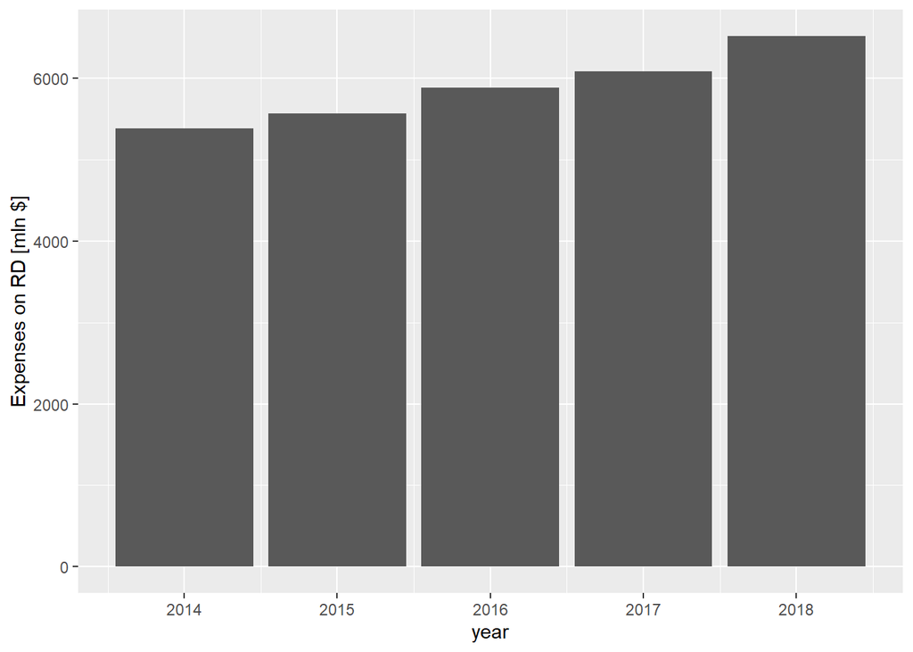

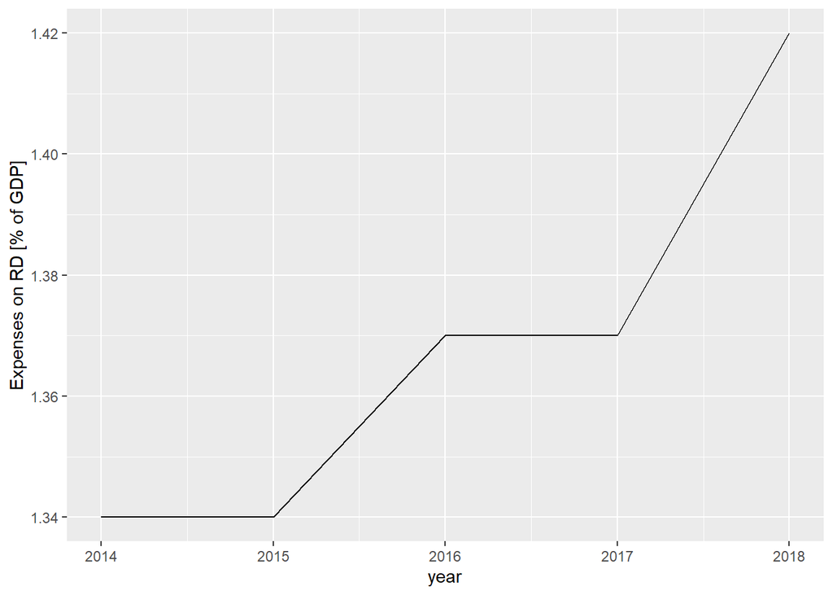

From the plot below we can conclude, that the expenses on R&D in the period 2014 - 2018 have changed by 0.08 % which corresponds to change by 1130.39 mln $ in expressed absolute terms.

## Population

### Population per Year

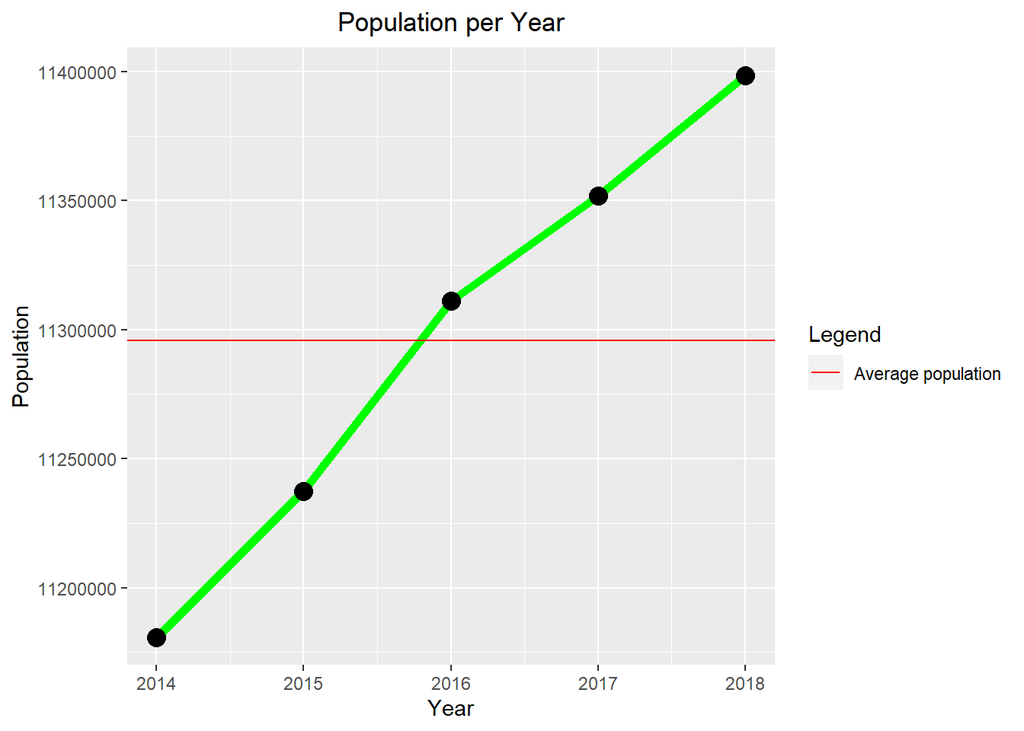

The average population between 2014 and 2018 in Belgium was 11 milions.

The highest population in Belgium was observed in year 2018.

The lowest population in Belgium was observed in year 2014.

### Birth rate

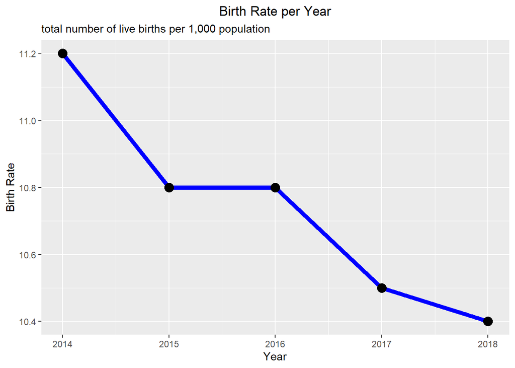

The highest birth rate in Belgium was observed in year 2014.

The lowest birth rate in Belgium was observed in year 2018.

### Life expectancy

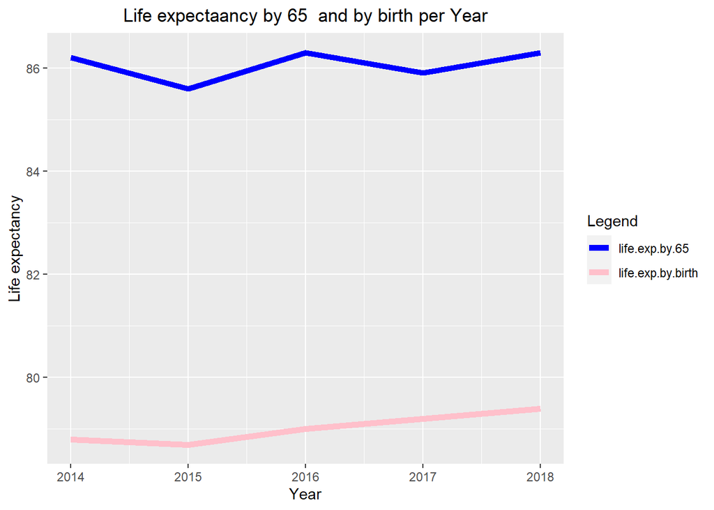

Life expectancy for people by 65 years old in 2014 was 86.

Life expectancy for people by 65 years old in 2018 was 86.

Life expectancy for people by birth in 2014 was 79.

Life expectancy for people by birth in 2018 was 79.

## Unemployment

### Short and long term unemployment

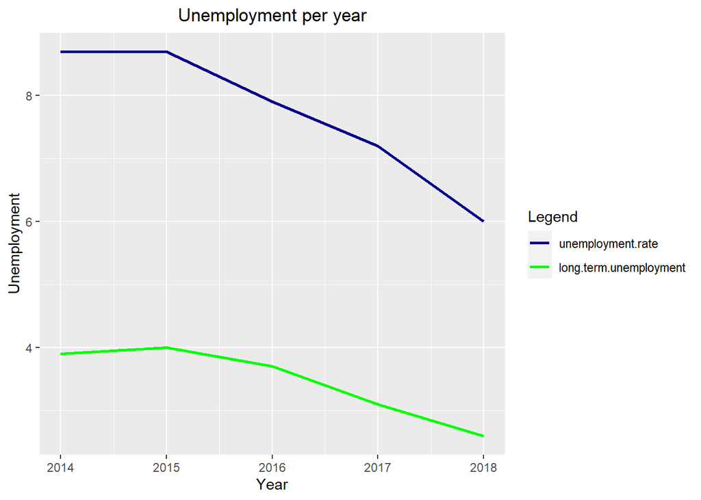

Unemployment rate in 2014 was 8.7.

Unemployment rate in 2018 was 6.

Long term unemployment rate in 2014 was 3.9.

Long term unemployment rate in 2018 was 2.6.

### Unemployment Table

Short term and long term unemployemt rate

| Year | Unemployment rate [%] | Long term unemployment rate [%] |
| --- | --- | --- |
| 2014 | 8.7 | 3.9 |
| 2015 | 8.7 | 4.0 |
| 2016 | 7.9 | 3.7 |
| 2017 | 7.2 | 3.1 |
| 2018 | 6.0 | 2.6 |

## Women situation

### Fertility rate

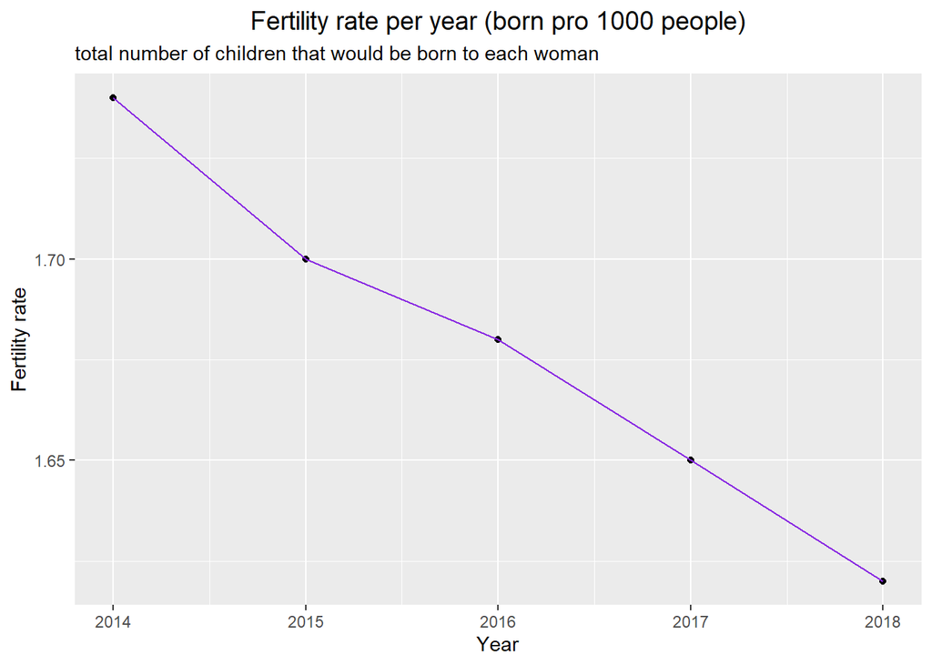

The average fertility rate between 2014 and 2018 in Belgium was 2.

The highest fertility rate in Belgium was observed in year 2014.

The lowest fertility rate in Belgium was observed in year 2018.

### Age at first child

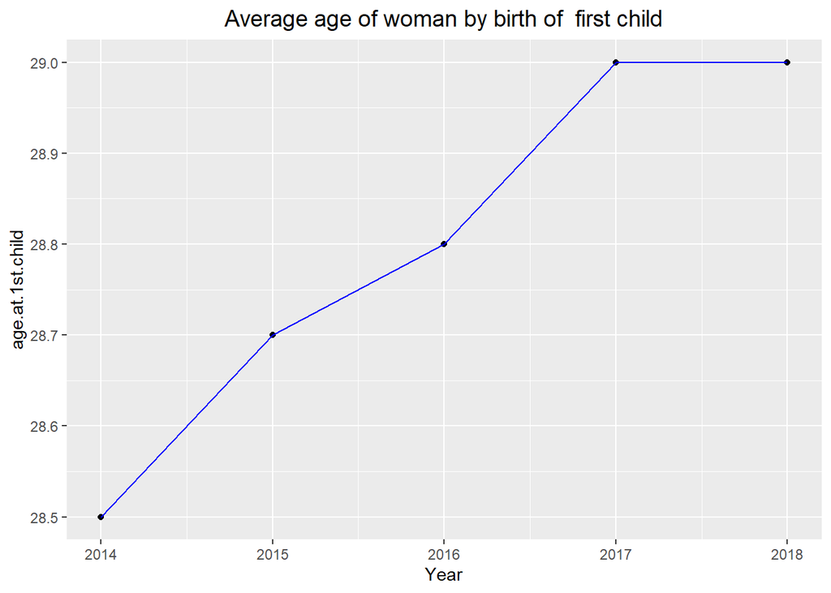

The highest average age of a woman while giving birth to the first child in Belgium was observed in year 2017.

The lowest average age of a woman while giving birth to the first child in Belgium was observed in year 2014.

### Gender pay gap

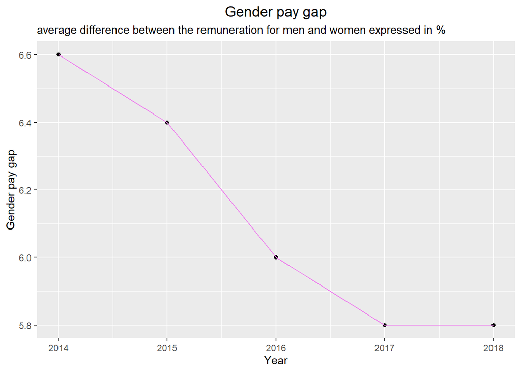

Gender pay gap is calculated as the average difference between the remuneration for men and women who are working. expressed in %.

The highest Gender pay gap in Belgium was observed in year 2014.

The lowest Gender pay gap in Belgium was observed in year 2017.